# 04_2 Test7 actual mock benchmark

Test7 decontamination analysis

2026-10-02

# 1 1. Scope

This benchmark uses the observed Test7 mock samples directly. The three Cell Mock samples and the DNA Mock are not simulated. An observed ASV assigned to one of the six MSA-2005 target genera is treated as expected; any other observed ASV is treated as off-target. Thus, the labels are operational taxonomic truth, not proof of the physical contamination source.

The contaminant calls are the pooled results already generated in script 06. Mocks were excluded when those methods were fitted, and the resulting calls are applied here to the mock samples as an external validation set.

```r
library(phyloseq)
library(dplyr)
library(tidyr)
library(ggplot2)
library(readr)
library(pROC)

input_path <- file.path("Phyloseq", "phy_F270R210_260921.rds")
method_dir <- file.path(
  "Results", "Test7", "06_combined_cross_method_validation"
)
output_dir <- file.path(
  "Results", "Test7", "04_2_actual_mock_benchmark"
)
dir.create(output_dir, recursive = TRUE, showWarnings = FALSE)

decontam_flag_path <- file.path(method_dir, "06_05_decontam_feature_flags.csv")
microbiem_flag_path <- file.path(
  method_dir, "06_15_MicrobIEM_threshold_feature_flags.csv"
)
scrub_flag_path <- file.path(
  method_dir, "06_17_SCRuB_nonspatial_threshold_feature_flags.csv"
)

stopifnot(
  file.exists(input_path),
  file.exists(decontam_flag_path),
  file.exists(microbiem_flag_path),
  file.exists(scrub_flag_path)
)

method_colors <- c(
  Prevalence = "#1B9E77",
  Frequency = "#D95F02",
  Combined = "#7570B3",
  MicrobIEM = "#66A61E",
  `SCRuB non-spatial` = "#E7298A"
)
theme_set(theme_bw(base_size = 11))
```

# 2 2. Actual mock samples and ASV truth

```r
expected_genera <- c(
  "Acinetobacter", "Corynebacterium", "Micrococcus",
  "Cutibacterium", "Staphylococcus", "Streptococcus"
)

expected_table <- data.frame(
  Genus = expected_genera,
  expected_abundance = rep(1 / length(expected_genera), length(expected_genera))
)

phy <- readRDS(input_path)
metadata <- data.frame(sample_data(phy), check.names = FALSE) |>
  tibble::rownames_to_column("SampleID") |>
  mutate(Cycle = sub("\\.0$", "", as.character(Cycle)))

cell_mock_ids <- metadata |>
  filter(!is.na(control_type), control_type == "Cell_mix", Cycle == "3") |>
  pull(SampleID)
dna_mock_ids <- metadata |>
  filter(!is.na(control_type), control_type == "DNA_mix") |>
  pull(SampleID)
mock_ids <- c(cell_mock_ids, dna_mock_ids)

count_table <- as(otu_table(phy), "matrix")
if (taxa_are_rows(phy)) count_table <- t(count_table)
count_table <- count_table[sample_names(phy), taxa_names(phy), drop = FALSE]

taxonomy <- data.frame(tax_table(phy), check.names = FALSE) |>
  tibble::rownames_to_column("ASV") |>
  mutate(
    Genus = if_else(is.na(Genus) | Genus == "", "Unclassified", as.character(Genus))
  )

mock_truth <- as.data.frame(as.table(count_table[mock_ids, , drop = FALSE])) |>
  rename(SampleID = Var1, ASV = Var2, reads = Freq) |>
  mutate(SampleID = as.character(SampleID), ASV = as.character(ASV)) |>
  filter(reads > 0) |>
  left_join(
    metadata |> select(SampleID, Subject, control_type),
    by = "SampleID"
  ) |>
  left_join(taxonomy, by = "ASV") |>
  mutate(
    mock_type = if_else(control_type == "Cell_mix", "Cell Mock", "DNA Mock"),
    truth = if_else(Genus %in% expected_genera, "Expected", "Off-target"),
    is_off_target = truth == "Off-target"
  )

mock_truth_summary <- mock_truth |>
  group_by(mock_type, SampleID, Subject) |>
  summarise(
    total_reads = sum(reads),
    observed_ASVs = n(),
    expected_ASVs = sum(!is_off_target),
    off_target_ASVs = sum(is_off_target),
    off_target_read_pct = 100 * sum(reads[is_off_target]) / sum(reads),
    .groups = "drop"
  )

write_csv(expected_table, file.path(output_dir, "04_2_01_expected_genera.csv"))
write_csv(mock_truth, file.path(output_dir, "04_2_02_actual_mock_ASV_truth.csv"))
write_csv(mock_truth_summary, file.path(output_dir, "04_2_03_actual_mock_summary.csv"))

knitr::kable(mock_truth_summary, digits = 3)
```

| mock_type | SampleID | Subject | total_reads | observed_ASVs | expected_ASVs | off_target_ASVs | off_target_read_pct |
| --- | --- | --- | --- | --- | --- | --- | --- |
| Cell Mock | 70_S70_L001 | Cell-Mock | 41382 | 126 | 9 | 117 | 10.981 |
| Cell Mock | 71_S71_L001 | Cell-Mock-1 | 48361 | 85 | 8 | 77 | 3.433 |
| Cell Mock | 72_S72_L001 | Cell-Mock-2 | 39637 | 104 | 10 | 94 | 6.380 |
| DNA Mock | 73_S73_L001 | DNA-Mock | 52189 | 95 | 8 | 87 | 7.471 |

# 3 3. Existing five-method calls

No method is refitted in this document. It uses the feature-level calls from script 06 so that all methods use the same Test7 input and negative controls. For MicrobIEM, the no-well-position setting (`Any detected`) is used. For SCRuB, the non-spatial result is used.

```r
mock_asvs <- unique(mock_truth$ASV)

decontam_flags <- read_csv(decontam_flag_path, show_col_types = FALSE) |>
  filter(batch_mode == "pooled") |>
  transmute(
    method = recode(
      method,
      prevalence = "Prevalence",
      frequency = "Frequency",
      combined = "Combined"
    ),
    threshold_parameter = "decontam threshold",
    threshold = as.numeric(threshold),
    ASV = feature_id,
    predicted_contaminant = contaminant
  )

decontam_settings <- decontam_flags |>
  distinct(method, threshold_parameter, threshold)

decontam_predictions <- tidyr::crossing(
  decontam_settings,
  ASV = mock_asvs
) |>
  left_join(
    decontam_flags,
    by = c("method", "threshold_parameter", "threshold", "ASV")
  ) |>
  mutate(predicted_contaminant = replace_na(predicted_contaminant, FALSE))

microbiem_flags <- read_csv(microbiem_flag_path, show_col_types = FALSE) |>
  filter(span_label == "Any detected") |>
  transmute(
    method = "MicrobIEM",
    threshold_parameter = "ratio threshold",
    threshold = as.numeric(ratio_threshold),
    ASV,
    predicted_contaminant = contaminant
  )

microbiem_settings <- microbiem_flags |>
  distinct(method, threshold_parameter, threshold)

microbiem_predictions <- tidyr::crossing(
  microbiem_settings,
  ASV = mock_asvs
) |>
  left_join(
    microbiem_flags,
    by = c("method", "threshold_parameter", "threshold", "ASV")
  ) |>
  mutate(predicted_contaminant = replace_na(predicted_contaminant, FALSE))

scrub_flags <- read_csv(scrub_flag_path, show_col_types = FALSE) |>
  transmute(
    method = "SCRuB non-spatial",
    threshold_parameter = "ASV removal-fraction cutoff",
    threshold = as.numeric(removal_fraction_cutoff),
    ASV,
    predicted_contaminant = affected
  )

scrub_settings <- scrub_flags |>
  distinct(method, threshold_parameter, threshold)

scrub_predictions <- tidyr::crossing(
  scrub_settings,
  ASV = mock_asvs
) |>
  left_join(
    scrub_flags,
    by = c("method", "threshold_parameter", "threshold", "ASV")
  ) |>
  mutate(predicted_contaminant = replace_na(predicted_contaminant, FALSE))

predictions <- bind_rows(
  decontam_predictions,
  microbiem_predictions,
  scrub_predictions
)
```

# 4 4. Classification metrics on actual mocks

The evaluation unit is an observed ASV-sample pair. Consequently, an ASV observed in all three Cell Mock samples contributes three observations, whereas an ASV observed only once contributes one.

```r
prediction_units <- predictions |>
  inner_join(
    mock_truth |>
      select(SampleID, Subject, mock_type, ASV, reads, Genus, truth, is_off_target),
    by = "ASV"
  )

threshold_metrics <- prediction_units |>
  group_by(mock_type, method, threshold_parameter, threshold) |>
  summarise(
    TP = sum(predicted_contaminant & is_off_target),
    TN = sum(!predicted_contaminant & !is_off_target),
    FP = sum(predicted_contaminant & !is_off_target),
    FN = sum(!predicted_contaminant & is_off_target),
    off_target_reads_removed_pct = 100 *
      sum(reads[predicted_contaminant & is_off_target]) /
      sum(reads[is_off_target]),
    expected_reads_removed_pct = 100 *
      sum(reads[predicted_contaminant & !is_off_target]) /
      sum(reads[!is_off_target]),
    .groups = "drop"
  ) |>
  mutate(
    Sensitivity_Recall = TP / (TP + FN),
    Specificity = TN / (TN + FP),
    Precision_PPV = if_else(TP + FP > 0, TP / (TP + FP), NA_real_),
    F1 = if_else(
      is.finite(Precision_PPV) & Precision_PPV + Sensitivity_Recall > 0,
      2 * Precision_PPV * Sensitivity_Recall /
        (Precision_PPV + Sensitivity_Recall),
      0
    ),
    Youden_J = Sensitivity_Recall + Specificity - 1
  )

raw_metrics <- mock_truth |>
  group_by(mock_type) |>
  summarise(
    method = "Raw: no ASV removed",
    TP = 0L,
    TN = sum(!is_off_target),
    FP = 0L,
    FN = sum(is_off_target),
    Sensitivity_Recall = 0,
    Specificity = 1,
    Precision_PPV = NA_real_,
    F1 = 0,
    Youden_J = 0,
    .groups = "drop"
  )

write_csv(threshold_metrics, file.path(output_dir, "04_2_04_threshold_metrics.csv"))
write_csv(raw_metrics, file.path(output_dir, "04_2_05_raw_classification_metrics.csv"))
```

# 5 5. Threshold-free AUROC

Continuous scores are reconstructed from each method’s saved threshold trajectory. ASVs absent from a method’s fitted feature table receive score 0 because the fitted method cannot flag them.

```r
decontam_scores <- decontam_predictions |>
  group_by(method, ASV) |>
  summarise(
    score = if_else(
      any(predicted_contaminant),
      1 - min(threshold[predicted_contaminant]),
      0
    ),
    .groups = "drop"
  )

microbiem_scores <- microbiem_predictions |>
  group_by(method, ASV) |>
  summarise(
    score = if_else(
      any(predicted_contaminant),
      max(threshold[predicted_contaminant]),
      0
    ),
    .groups = "drop"
  )

scrub_scores <- scrub_predictions |>
  group_by(method, ASV) |>
  summarise(
    score = if_else(
      any(predicted_contaminant),
      max(threshold[predicted_contaminant]),
      0
    ),
    .groups = "drop"
  )

score_units <- bind_rows(decontam_scores, microbiem_scores, scrub_scores) |>
  inner_join(
    mock_truth |> select(SampleID, mock_type, ASV, is_off_target),
    by = "ASV"
  )

auc_parts <- list()
roc_parts <- list()
part_index <- 0L

for (mock_name in c("Cell Mock", "DNA Mock")) {
  for (method_name in names(method_colors)) {
    score_data <- score_units |>
      filter(mock_type == mock_name, method == method_name)

    roc_fit <- pROC::roc(
      response = score_data$is_off_target,
      predictor = score_data$score,
      levels = c(FALSE, TRUE),
      direction = "<",
      quiet = TRUE
    )

    part_index <- part_index + 1L
    auc_parts[[part_index]] <- data.frame(
      mock_type = mock_name,
      method = method_name,
      AUROC = as.numeric(pROC::auc(roc_fit))
    )

    roc_coordinates <- data.frame(pROC::coords(
      roc_fit,
      x = "all",
      ret = c("specificity", "sensitivity"),
      transpose = FALSE
    )) |>
      mutate(
        mock_type = mock_name,
        method = method_name,
        false_positive_rate = 1 - specificity
      )
    roc_parts[[part_index]] <- roc_coordinates
  }
}

auc_summary <- bind_rows(auc_parts)
roc_data <- bind_rows(roc_parts)

best_metrics <- threshold_metrics |>
  group_by(mock_type, method) |>
  arrange(desc(Youden_J), desc(F1), threshold, .by_group = TRUE) |>
  slice_head(n = 1) |>
  ungroup() |>
  left_join(auc_summary, by = c("mock_type", "method")) |>
  mutate(
    mock_type = factor(mock_type, levels = c("Cell Mock", "DNA Mock")),
    method = factor(method, levels = names(method_colors))
  ) |>
  arrange(mock_type, method)

write_csv(auc_summary, file.path(output_dir, "04_2_06_AUROC.csv"))
write_csv(best_metrics, file.path(output_dir, "04_2_07_best_Youden_summary.csv"))
write_csv(roc_data, file.path(output_dir, "04_2_08_ROC_coordinates.csv"))

knitr::kable(
  best_metrics |>
    select(
      mock_type, method, threshold_parameter, threshold,
      TP, TN, FP, FN, Sensitivity_Recall, Specificity,
      Precision_PPV, F1, Youden_J, AUROC,
      off_target_reads_removed_pct, expected_reads_removed_pct
    ),
  digits = 3
)
```

| mock_type | method | threshold_parameter | threshold | TP | TN | FP | FN | Sensitivity_Recall | Specificity | Precision_PPV | F1 | Youden_J | AUROC | off_target_reads_removed_pct | expected_reads_removed_pct |
| --- | --- | --- | --- | --- | --- | --- | --- | --- | --- | --- | --- | --- | --- | --- | --- |
| Cell Mock | Prevalence | decontam threshold | 0.9 | 202 | 13 | 14 | 86 | 0.701 | 0.481 | 0.935 | 0.802 | 0.183 | 0.581 | 84.530 | 85.164 |
| Cell Mock | Frequency | decontam threshold | 0.7 | 149 | 22 | 5 | 139 | 0.517 | 0.815 | 0.968 | 0.674 | 0.332 | 0.670 | 61.571 | 64.701 |
| Cell Mock | Combined | decontam threshold | 0.7 | 173 | 17 | 10 | 115 | 0.601 | 0.630 | 0.945 | 0.735 | 0.230 | 0.595 | 70.342 | 84.727 |
| Cell Mock | MicrobIEM | ratio threshold | 0.5 | 174 | 17 | 10 | 114 | 0.604 | 0.630 | 0.946 | 0.737 | 0.234 | 0.555 | 66.415 | 84.727 |
| Cell Mock | SCRuB non-spatial | ASV removal-fraction cutoff | 0.2 | 107 | 17 | 10 | 181 | 0.372 | 0.630 | 0.915 | 0.528 | 0.001 | 0.433 | 35.108 | 84.727 |
| DNA Mock | Prevalence | decontam threshold | 0.2 | 24 | 8 | 0 | 63 | 0.276 | 1.000 | 1.000 | 0.432 | 0.276 | 0.609 | 48.089 | 0.000 |
| DNA Mock | Frequency | decontam threshold | 0.7 | 48 | 7 | 1 | 39 | 0.552 | 0.875 | 0.980 | 0.706 | 0.427 | 0.716 | 73.096 | 29.725 |
| DNA Mock | Combined | decontam threshold | 0.4 | 40 | 7 | 1 | 47 | 0.460 | 0.875 | 0.976 | 0.625 | 0.335 | 0.639 | 59.349 | 15.626 |
| DNA Mock | MicrobIEM | ratio threshold | 0.5 | 55 | 5 | 3 | 32 | 0.632 | 0.625 | 0.948 | 0.759 | 0.257 | 0.558 | 79.713 | 45.612 |
| DNA Mock | SCRuB non-spatial | ASV removal-fraction cutoff | 0.7 | 20 | 7 | 1 | 67 | 0.230 | 0.875 | 0.952 | 0.370 | 0.105 | 0.487 | 24.057 | 29.725 |

# 6 6. Figures

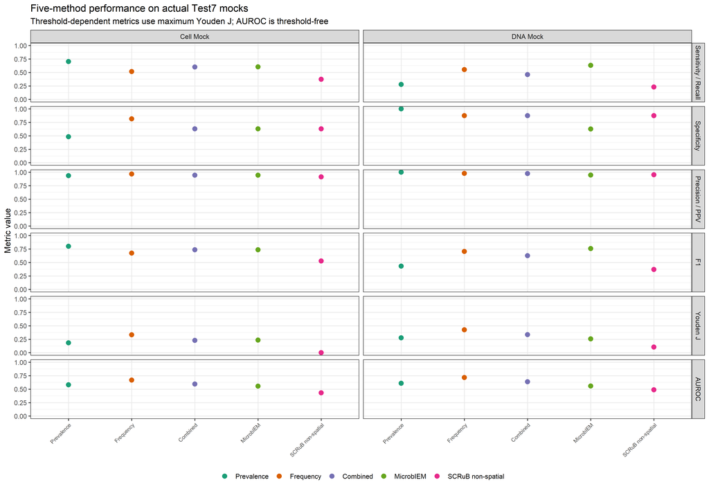

```r
metric_plot_data <- best_metrics |>
  select(
    mock_type, method,
    Sensitivity_Recall, Specificity, Precision_PPV, F1, Youden_J, AUROC
  ) |>
  pivot_longer(
    cols = c(
      Sensitivity_Recall, Specificity, Precision_PPV, F1, Youden_J, AUROC
    ),
    names_to = "metric",
    values_to = "value"
  ) |>
  mutate(
    metric = recode(
      metric,
      Sensitivity_Recall = "Sensitivity / Recall",
      Precision_PPV = "Precision / PPV",
      Youden_J = "Youden J"
    ),
    metric = factor(
      metric,
      levels = c(
        "Sensitivity / Recall", "Specificity", "Precision / PPV",
        "F1", "Youden J", "AUROC"
      )
    )
  )

p_metrics <- ggplot(
  metric_plot_data,
  aes(method, value, color = method)
) +
  geom_point(size = 2.7) +
  facet_grid(metric ~ mock_type) +
  scale_color_manual(values = method_colors) +
  scale_y_continuous(limits = c(0, 1)) +
  labs(
    title = "Five-method performance on actual Test7 mocks",
    subtitle = "Threshold-dependent metrics use maximum Youden J; AUROC is threshold-free",
    x = NULL, y = "Metric value", color = NULL
  ) +
  theme(
    axis.text.x = element_text(angle = 45, hjust = 1, size = 7),
    legend.position = "bottom"
  )

print(p_metrics)
```

```r
ggsave(
  file.path(output_dir, "04_2_01_actual_mock_metrics.png"),
  p_metrics, width = 13, height = 9, dpi = 300
)
```

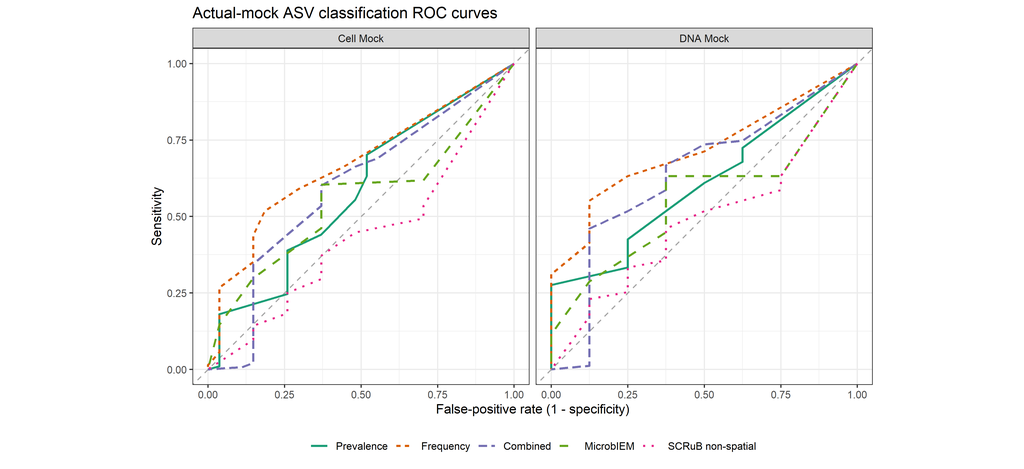

```r
roc_plot_data <- roc_data |>
  mutate(
    mock_type = factor(mock_type, levels = c("Cell Mock", "DNA Mock")),
    method = factor(method, levels = names(method_colors))
  )

p_roc <- ggplot(
  roc_plot_data,
  aes(false_positive_rate, sensitivity, color = method, linetype = method)
) +
  geom_abline(slope = 1, intercept = 0, linetype = 2, color = "grey65") +
  geom_path(linewidth = 0.9) +
  facet_wrap(~mock_type, nrow = 1) +
  scale_color_manual(values = method_colors) +
  coord_equal() +
  labs(
    title = "Actual-mock ASV classification ROC curves",
    x = "False-positive rate (1 - specificity)",
    y = "Sensitivity",
    color = NULL,
    linetype = NULL
  ) +
  theme(legend.position = "bottom")

print(p_roc)
```

```r
ggsave(
  file.path(output_dir, "04_2_02_actual_mock_ROC.png"),
  p_roc, width = 12, height = 5.5, dpi = 300
)
```

# 7 7. Verification and interpretation boundary

```r
mock_unit_counts <- mock_truth |>
  count(mock_type, name = "expected_units")

metric_unit_check <- threshold_metrics |>
  mutate(observed_units = TP + TN + FP + FN) |>
  left_join(mock_unit_counts, by = "mock_type")

verification <- data.frame(
  check = c(
    "Three Cell Mock samples and one DNA Mock were included",
    "Both expected and off-target ASVs occur in each mock type",
    "All five methods produced threshold results",
    "All five methods produced AUROC for both mock types",
    "Every confusion matrix contains every observed mock ASV-sample unit",
    "All metrics are within their valid ranges"
  ),
  passed = c(
    length(cell_mock_ids) == 3L & length(dna_mock_ids) == 1L,
    all((mock_truth |> count(mock_type, truth) |> count(mock_type))$n == 2L),
    setequal(unique(threshold_metrics$method), names(method_colors)),
    nrow(auc_summary) == 10L & all(is.finite(auc_summary$AUROC)),
    all(metric_unit_check$observed_units == metric_unit_check$expected_units),
    all(is.na(threshold_metrics$Sensitivity_Recall) |
          threshold_metrics$Sensitivity_Recall >= 0 &
          threshold_metrics$Sensitivity_Recall <= 1) &
      all(is.na(threshold_metrics$Specificity) |
            threshold_metrics$Specificity >= 0 &
            threshold_metrics$Specificity <= 1) &
      all(is.na(threshold_metrics$Precision_PPV) |
            threshold_metrics$Precision_PPV >= 0 &
            threshold_metrics$Precision_PPV <= 1) &
      all(is.na(threshold_metrics$F1) |
            threshold_metrics$F1 >= 0 & threshold_metrics$F1 <= 1) &
      all(threshold_metrics$Youden_J >= -1 & threshold_metrics$Youden_J <= 1) &
      all(auc_summary$AUROC >= 0 & auc_summary$AUROC <= 1)
  )
)

write_csv(verification, file.path(output_dir, "04_2_09_verification.csv"))
knitr::kable(verification)
```

| check | passed |
| --- | --- |
| Three Cell Mock samples and one DNA Mock were included | TRUE |
| Both expected and off-target ASVs occur in each mock type | TRUE |
| All five methods produced threshold results | TRUE |
| All five methods produced AUROC for both mock types | TRUE |
| Every confusion matrix contains every observed mock ASV-sample unit | TRUE |
| All metrics are within their valid ranges | TRUE |

```r
if (!all(verification$passed)) stop("One or more actual-mock checks failed.")
```

Sensitivity here means removal of observed off-target ASVs. Specificity means retention of observed ASVs assigned to the six expected genera. A flagged ASV within an expected genus is counted as a false positive even if that particular ASV is not the intended strain, which is a conservative genus-level definition. The DNA Mock contains one sample, so its uncertainty must not be interpreted as equivalent to replicated validation.